# Importancia del cacao en Mexico y en el mundo

Bruno Axel Santiago Rodriguez

8 de marzo del 2021

NATURALEZA: árbol procedente de América, que puede llegar a medir hasta 15 metros de altura, regularmente suele medir de 4 a 6 metros, este árbol solamente puede desarrollarse en tierras tropicales bajo la sombra y requiere de suelos muy ricos en materia orgánica, el fruto del cacao recibe el nombre de “vaina de cacao”, que posee una corteza rugosa de aproximadamente 3 centímetros, mide entre 15-20 cm, puede llegar a pesar hasta 500 gramos, esto puede variar dependiendo del origen y variedad de la vaina, este fruto está lleno de una pulpa dulce y mucilagosa, también llamada “baba de cacao” en America del Sur; cada fruto puede proporcionar hasta 50 semillas; estas semillas suelen tener un color blanco, durante el proceso de secado toman un color violeta o marrón rojizo, existen variedades raras de cacao blanco, en donde las semillas permanecen blancas durante todo este proceso, sus granos poseen un sabor más intenso, con pocos aromas y son amargos o ácidos. Históricamente, se dice que este tipo de cacao blanco era cultivado en Nicaragua por los pueblos Rama; la semilla fermentada y secada recibe el nombre de grano de cacao, estos se utilizan como ingrediente principal en la elaboración de chocolate, sin embargo, tambien destacan por su elaboracion con cacao la salsa de mole, el téjate, jaleas y mermeladas que tienen un valor cultural alto en regiones idigenas de Mexico. La composición del cacao es muy amplia, se puede destacar el alto nivel de energía que aporta, beneficiando a las personas que tienen una intensa actividad física, además cuenta con un alto índice de grasas saturadas, monoinsaturadas y polinsaturadas, hidratos de carbono y proteínas, así como magnesio, fósforo, potasio, teobromina, cafeína, antioxidantes y agua.

VALOR DE USO: se le pueden dar distintos usos, el mas comun es como alimento, que lo podemos ver en la elaboración del chocolate en barra o en polvo, para lo cual se utiliza la grasa que se obtiene al triturar su fruto una vez secado y fermentado, de este fruto se obtiene el polvo de cacao y la manteca de cacao, ambos ingredientes se mezclan junto a azúcares refinados y leche; pueden surgir distintos tipos de chocolate, dependiendo de la cantidad que se utilice de cada ingrediente; ademas en algunos alimentos puede llegarse a utilizar como saborizante o aromatizante. La adición de cada uno de estos ingredientes permite que el chocolate tenga más aportes nutritivos, además de los ya presentes en el cacao, como la vitamina A, la vitamina B, el calcio y el hierro. Existen bebidas derivadas del cacao, que datan de hace siglos, provenientes de la cultura indígena, particularmente en los pueblos chontal de Tabasco y zapoteco de los Valles Centrales y el Istmo de Oaxaca, es donde actualmente se conservan estas tradiciones.

Se puede utilizar como remedio natural, los tratamientos sirven para curar o aliviar el cansancio, la delgadez extrema, la fiebre, la anemia o los problemas renales e intestinales, ademas de prevenir diversas enfermedades, como las cardiovasculares y cerebrovasculares; algunos tipos de cáncer y otras enfermedades del sistema nervioso como el Alzheimer y el Parkinson, todo esto de acuerdo con el Consejo Europeo de Información sobre la Alimentación; su descubrimiento ha permitido su desarrollo para más de cien usos medicinales. Además, se puede utilizar como cosmético, ya que la manteca de cacao sirve como tratamiento para algunos problemas de la piel como las arrugas, las estrías o para el cabello, tambien se puede hacer jabones para el cuerpo y a partir de ceniza de cacao se puede hacer abono para hacer a la tirra fertil. En nuestro país, Tabasco, aporta el 66.9% del total de producción nacional con 17 mil 281 toneladas cosechadas, Chiapas aporta el 32.9% con 9 mil 346 toneladas y Guerrero el 0.2% con 236 toneladas, siendo el cacao mexicano uno de los mas buscados a nivel internacionl por las caracteristicas unicas que posee, que son el fino aroma y fino sabor, que no se le compara con ningun otro cacao en el mundo.

VALOR DE CAMBIO: el cacao históricamente en México era utilizado por las tribus Mayas, Aztecas e Incas hace más de 2.500 años, como remedio medicinal y como moneda de cambio, en los primeros años de colonia el cacao seguía siendo utilizado como moneda de cambio en algunas regiones, los conquistadores españoles lo utilizaban para pagarle a los indígenas por su trabajo, un día de trabajo equivalía a 25 cacaos y para salir de la cárcel se cobraban 40 cacaos. En México hay un escaso apoyo al comercio y producción del cacao, lo que produce una baja producción mundial, se puede señalar que, si se incorporaran productos artesanales de mejor calidad, esto haría que se abrieran nuevas redes comerciales y se les daría un valor agregado a estos productos, lo que generaría la conservación la riqueza cultural que acompaña el desarrollo de este cultivo en algunas entidades federativas de nuestro país. Las exportaciones de cacao mexicano son pequeñas, de 621 toneladas exportadas el 79% se destinan a Bélgica, y a empresas norteamericanas de chocolate gourmet quienes buscan el cacao mexicano por su fino aroma que lo hace diferente a otros. El consumo de cacao per cápita en México es de 0.5 kg, representando el 0.6% del gasto total realizado en alimentos y bebidas por las familias mexicanas. La Secretaria de Agricultura estima que para 2030 el consumo y la producción nacional de cacao tenga un crecimiento de 76.97 y 19.49%, respectivamente. En Mexico se espera que los estados de Nayarit, Jalisco, Colima Michoacan, San Luis Potosi, Campeche y Quintana Roo en los proximos años sean productores de cacao, ya que se les considera con el potencial para lograrlo, ya que cuentan con un tipo de clima y suelo muy buenos para que se pueda desarrollar el arbol de cacao.

VALOR: en el país existe un déficit de producción y consumo de cacao, esto hace que para satisfacer la demanda interna se importe cacao de Ecuador, Costa de Marfil, República Dominicana, Colombia y Ghana. Cabe señalar que, durante 2016, el valor de las exportaciones de granos de cacao en Ghana ascendió a 621 millones de dólares. Durante 2020, en nuestro pais los principales destinos comerciales de cacao en Grano, Entero o Partido, Crudo o Tostado fueron: Suiza (353 Mil Dolares), Estados Unidos (127 Mil Dolares), Japón (82.2 Mil Dolares), Reino Unido (74.8 Mil Dolares) y Nueva Zelandia (12.4 Mil Dolares). En este mismo año, la entidad federativa con mas compra de cacao fue la Ciudad de Mexico, con un valor de 91.7 Millones de Dolares, esto se debe a que en esta zona urbana se encuentras muchas chocolateras importantes a nivel nacional. Hasta mediados del siglo pasado, los fabricantes solían tostar su propio cacao, además de elaborar productos semi-acabados de cacao; también comercializaban sus propios productos, esta costumbre ha desaparecido casi por completo, en la actualidad, solo se pueden distinguir a dos grupos en la industria cacaotera: elaboradores de productos semi-acabados de cacao y fabricantes de chocolate. Durante febrero del 2021, el precio del cacao era de $48.99 pesos mexicanos por kilo.

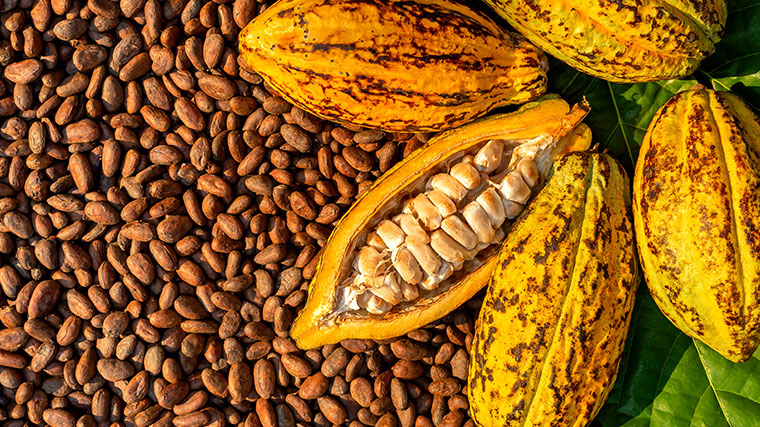

Fuente: Cacao Mexico

## Bibliografía

1. https://www.gob.mx/inpi/articulos/libro-interactivo-cacao-alimentos-y-bebidas-de-los-pueblos-indigenas-de-mexico
2. CuidatePlus. (2021). Cacao. 7 de marzo del 2021, de CuidatePlus Sitio web: https://cuidateplus.marca.com/alimentacion/diccionario/cacao.html
3. Cacao México. (2021). Cacao. 8 de marzo del 2021, de Cacao México Sitio web: https://cacaomexico.org/
4. https://datamexico.org/es/profile/product/cocoa-beans-whole-or-broken-raw-or-roasted?exportsGeoSelector=2
5. https://www.uv.mx/cienciahombre/revistae/vol25num3/articulos/xocolatl/
6. https://www.icco.org/growing-cocoa/
7. https://www.elsevier.es/es-revista-revista-internacional-acupuntura-279-articulo-el-cacao-planta-medicinal-deleite-S1887836909731606
8. http://siaprendes.siap.gob.mx/contenidos/3/02-cacao/contexto-6.html